# ETC5523: Communicating with Data

Tutorial 2

Author

Michael Lydeamore

Published

February 1, 2001

## 🎯 Objectives

- interpret and apply HTML/CSS to customise the look of web documents
- modify the look of HTML documents produced by R Markdown

**Preparation**

1. You should do 2A as much as possible *before the tutorial*.
2. Download `tutorial-02-supp.qmd`.
3. Install R-package

```r
remotes::install_github("joachim-gassen/tidycovid19")
```

## 🛠️ Exercise 2A

**HTML/CSS basics**

Go through the:

- HTML tutorials:
  - [Introduction](https://www.w3schools.com/html/html_intro.asp)
  - [Basic](https://www.w3schools.com/html/html_basic.asp)
  - [Elements](https://www.w3schools.com/html/html_elements.asp)
  - [Attributes](https://www.w3schools.com/html/html_attributes.asp)
  - [Links](https://www.w3schools.com/html/html_links.asp)
  - [Images](https://www.w3schools.com/html/html_images.asp)
  - [Table](https://www.w3schools.com/html/html_tables.asp)
  - [Class](https://www.w3schools.com/html/html_classes.asp)
  - [Id](https://www.w3schools.com/html/html_id.asp)
  - [Input types](https://www.w3schools.com/html/html_form_input_types.asp)
- CSS tutorials:
  - [Introduction](https://www.w3schools.com/css/css_intro.asp)
  - [Syntax](https://www.w3schools.com/css/css_syntax.asp)
  - [Selectors](https://www.w3schools.com/css/css_selectors.asp)
  - [Color](https://www.w3schools.com/css/css_colors.asp)
  - [Borders](https://www.w3schools.com/css/css_border.asp)
  - [Margins](https://www.w3schools.com/css/css_margin.asp)
  - [Paddings](https://www.w3schools.com/css/css_padding.asp)
  - [Text](https://www.w3schools.com/css/css_text.asp)
  - [Table](https://www.w3schools.com/css/css_table.asp)
  - [Align](https://www.w3schools.com/css/css_align.asp)

and the exercises therein. Note: you do not need to click on the “Next >” button as that progresses to the next tutorial. We’ve selected the 10 most important tutorials from the HTML and CSS sections. If time permits, feel free to go through other tutorials.

## 🛠️ Exercise 2B

**Test your knowledge in HTML/CSS**

This quiz is not assessed, it is only for your own learning.

1. What does HTML stand for?

   Hyperlinks and Text Markup Language Home Tool Markup Language Hyper Text Markup Language
2. Who governs the standards for CSS?

   Mozilla Google World Wide Web Consortium Microsoft Apple
3. Which is the correct HTML element for the largest heading?

   `<h1>` `<h6>` `<head>` `<heading>`
4. Which of the following is the correct HTML for adding a background color?

   `<body bg="yellow">` `<body style="background-color:yellow;">` `<background>yellow</background>`
5. What is the correct HTML for creating a hyperlink?

   `<a url="http://www.w3schools.com">W3Schools.com</a>` `<a>http://www.w3schools.com</a>` `<a name="http://www.w3schools.com">W3Schools.com</a>` `<a href="http://www.w3schools.com">W3Schools</a>`
6. Inline elements are normally displayed without starting a new line.

   True False
7. How can you make a bulleted list?

   `<ul>` `<dl>` `<list>` `<ol>`
8. What is the correct HTML for making a checkbox?

   `<checkbox>` `<input type="check">` `<input type="checkbox">` `<check>`
9. What is the correct HTML for making a drop-down list?

   `<input type="dropdown">` `<select>` `<input type="list">` `<list>`
10. Which of the following is the correct HTML for inserting an image?

    `<img src="image.gif" alt="MyImage">` `<img alt="MyImage">image.gif</img>` `<image src="image.gif" alt="MyImage">` `<img href="image.gif" alt="MyImage">`
11. An `<iframe>` is used to display a web page within a web page

    True False
12. HTML comments start with `<!--` and end with `-->`

    True False
13. Which HTML element defines navigation links?

    `<navigation>` `<navigate>` `<nav>`
14. Which HTML element is used to specify a header for a document or section?

    `<head>` `<header>` `<section>`
15. What does CSS stand for?

    Computer Style Sheets Cascading Style Sheets Colorful Style Sheets Creative Style Sheets
16. What is the correct HTML for referring to an external style sheet?

    `<link rel="stylesheet" type="text/css" href="mystyle.css">` `<stylesheet>mystyle.css</stylesheet>` `<style src="mystyle.css">`
17. Which HTML tag is used to define an internal stylesheet?

    `<style>` `<script>` `<css>`
18. Which HTML attribute is used to define inline styles?

    styles style class font
19. Which one of the following is correct CSS syntax?

    `{body;color:black;}` `{body:color=black;}` `body:color=black;` `body {color: black;}`
20. How do you insert a comment in a CSS file?

    // this is a comment /* this is a comment */ # this is a comment // this is a comment //
21. Which property is used to change the background color?

    background-color color bgcolor
22. How do you add a background color for all `<h1>` elements?

    `all.h1 {background-color:#FFFFFF;}` `h1.all {background-color:#FFFFFF;}` `h1 {background-color:#FFFFFF;}`
23. Which CSS property is used to change the text color of an element?

    fgcolor text-color color
24. Which CSS property controls the text size?

    `<p style="font-size:bold;">` `<p style="font-weight:bold;">` `p {font-weight:bold;}` `p {font-style:bold;}`
26. How do you select an element with id ‘demo’?

    `*demo` `.demo` `#demo` `demo`
27. How do you select elements with class name ‘test’?

    `#test` `.test` `*test` `test`
28. How do you select all `p` elements inside a `div` element?

    `div p` `div + p` `div.p`
29. Which of the following would be used to create an ID called header which has a width of 750px, a height of 30px and the color of the text is black?

    `.header { width: 750px; height: 30px; color: "black"; }` `.header { width: 750px; height: 30px; text-color: "black"; }` `#header { width: 750px; height: 30px; color: "black"; }` `#header { width: 750px; height: 30px; text-color: "black"; }`

## 🛠️ Exercise 2C

**Modify the look of your Rmd HTML documents**

1. Open `tutorial-02-supp.qmd` and render. Inspect the HTML output.
2. Modify the qmd file that when you knit, the HTML output looks like below:

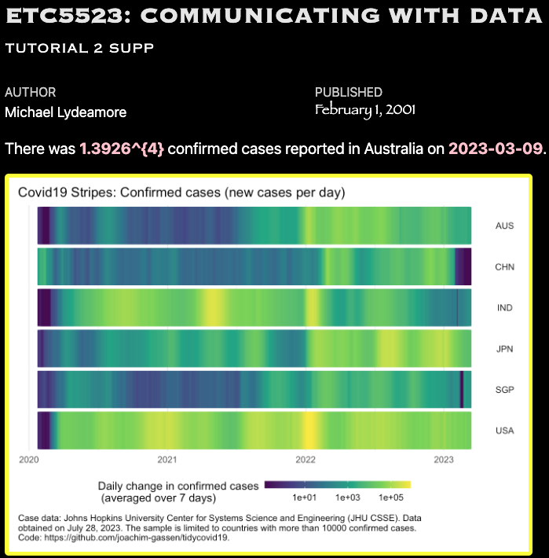